# Prosper Loan Data Exploration

## By Omar Soliman

Date 11/09/2022

## Investigation Overview

> My goal with this investigation is to figure out what features can be used to predict default on credit, Also i would like to check what are major factors connected with prosper credit rating.

## Dataset Overview

> This data set contains information on peer to peer loans facilitated by credit company Prosper. There are 113,937 loans with 81 variables. For the purpose of this investigation I've taken the following variables: Term, LoanStatus, BorrowerRate, ProsperRating (Alpha), ListingCategory (numeric), EmploymentStatus, DelinquenciesLast7Years, StatedMonthlyIncome, TotalProsperLoans, LoanOriginalAmount, LoanOriginationDate, Recommendations and Investors.

**Observation 1:**

- The majority of borrowers are employed and all other categories as small part of borrowers.
- In small Group full time has highest, after that self empolyed are there and so on.

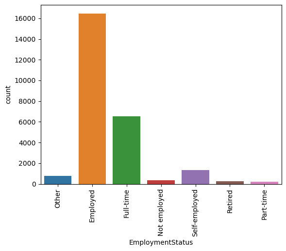

**Observation 2:**

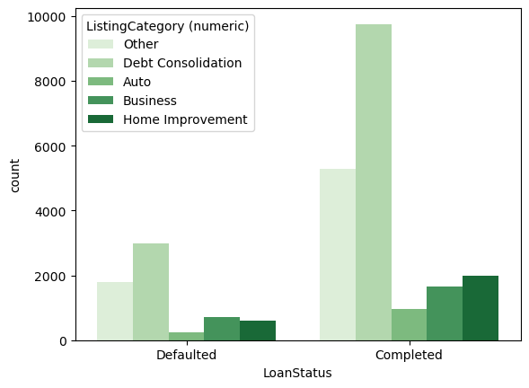

## Rating, Loan Amount and Loan Status

**Observation :**

- Except for the lowest ratings defaulted credits tend to be larger than completed.
- Most of the defaulted credits comes from individuals with low Prosper rating.

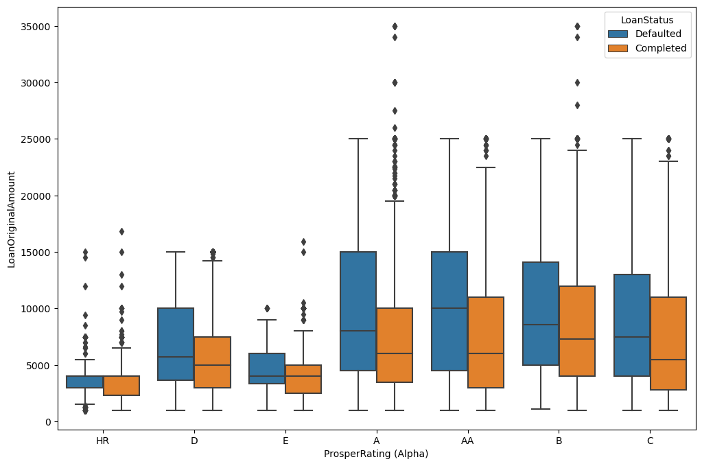